# Practical Machine Learning - Exercise Prediction

MahVal

October 6, 2018

## Overview

People can track the quantity of thier activity usually quantify how much of a particular activity they do, but they rarely quantify how well they do it. The main goal of this project was to use data from accelerometers on the belt, forearm, arm, and dumbell of 6 different participants, in order to predict the manner in which they did the exercise.The participants were asked to perform barbell lifts correctly and incorrectly in five different ways. More information is available from the website here: http://groupware.les.inf.puc-rio.br/har (see the section on the Weight Lifting Exercise Dataset).

# Data Sources

The training data were available at:

https://d396qusza40orc.cloudfront.net/predmachlearn/pml-training.csv

The testing data were available at:

https://d396qusza40orc.cloudfront.net/predmachlearn/pml-testing.csv

The original source of the full data can be found at: http://groupware.les.inf.puc-rio.br/har.

# Step 1: Loading required packages

```r
r = getOption("repos")
r["CRAN"] = "http://cran.us.r-project.org"
options(repos = r)
install.packages("weatherData")
```

```r
#install required packages:
install.packages("corrplot")
install.packages('caret', dependencies = TRUE)
install.packages("gbm")
library(dplyr)
library(gbm)
library(caret)
library(rpart)
library(rpart.plot)
library(RColorBrewer)
library(rattle)
library(randomForest)
library(knitr)
library(corrplot)
```

# Step 2: Loading and reading dataset

```r
# set the URL for the download
UrlTrain <- "http://d396qusza40orc.cloudfront.net/predmachlearn/pml-training.csv"
UrlTest  <- "http://d396qusza40orc.cloudfront.net/predmachlearn/pml-testing.csv"

# download the datasets
TrainData <- read.csv(UrlTrain, header = T, na.strings = c("", "NA", "#DIV/0!"))
TestData <- read.csv(UrlTest, header = T, na.strings = c("", "NA", "#DIV/0!"))

dim(TrainData)
```

```
## [1] 19622   160
```

```r
dim(TestData)
```

```
## [1]  20 160
```

```r
head(TrainData, n = 5)
```

|  | X | user_name | raw_timestamp_part_1 | raw_timestamp_part_2 | cvtd_timestamp | new_window | num_window | roll_belt | pitch_belt | yaw_belt | total_accel_belt | kurtosis_roll_belt | kurtosis_picth_belt | kurtosis_yaw_belt | skewness_roll_belt | skewness_roll_belt.1 | skewness_yaw_belt | max_roll_belt | max_picth_belt | max_yaw_belt | min_roll_belt | min_pitch_belt | min_yaw_belt | amplitude_roll_belt | amplitude_pitch_belt | amplitude_yaw_belt | var_total_accel_belt | avg_roll_belt | stddev_roll_belt | … |
| --- | --- | --- | --- | --- | --- | --- | --- | --- | --- | --- | --- | --- | --- | --- | --- | --- | --- | --- | --- | --- | --- | --- | --- | --- | --- | --- | --- | --- | --- | --- |
| 1 | 1 | carlitos | 1323084231 | 788290 | 05/12/2011 11:23 | no | 11 | 1.41 | 8.07 | -94.4 | 3 | NA | NA | NA | NA | NA | NA | NA | NA | NA | NA | NA | NA | NA | NA | NA | NA | NA | NA | … |
| 2 | 2 | carlitos | 1323084231 | 808298 | 05/12/2011 11:23 | no | 11 | 1.41 | 8.07 | -94.4 | 3 | NA | NA | NA | NA | NA | NA | NA | NA | NA | NA | NA | NA | NA | NA | NA | NA | NA | NA | … |
| 3 | 3 | carlitos | 1323084231 | 820366 | 05/12/2011 11:23 | no | 11 | 1.42 | 8.07 | -94.4 | 3 | NA | NA | NA | NA | NA | NA | NA | NA | NA | NA | NA | NA | NA | NA | NA | NA | NA | NA | … |
| 4 | 4 | carlitos | 1323084232 | 120339 | 05/12/2011 11:23 | no | 12 | 1.48 | 8.05 | -94.4 | 3 | NA | NA | NA | NA | NA | NA | NA | NA | NA | NA | NA | NA | NA | NA | NA | NA | NA | NA | … |
| 5 | 5 | carlitos | 1323084232 | 196328 | 05/12/2011 11:23 | no | 12 | 1.48 | 8.07 | -94.4 | 3 | NA | NA | NA | NA | NA | NA | NA | NA | NA | NA | NA | NA | NA | NA | NA | NA | NA | NA | … |

# Step 3: Cleaning and preparation of dataset

```r
# Remove variables that are mostly NA
TrainData <- Filter(function(x)!all(is.na(x)), TrainData)
TestData <- Filter(function(x)!all(is.na(x)), TestData)

# Remove all rows where new_window = Yes, since those are summary rows
TrainData <- filter(TrainData, TrainData[, 6] == "no")
TestData <- filter(TestData, TestData[, 6] == "no")

# Remove variables with Nearly Zero Variance
NearZero <- nearZeroVar(TrainData)
TrainData <- TrainData[, -NearZero]
NearZero <- nearZeroVar(TestData)
TestData <- TestData[, -NearZero]

# Remove identification only variables (columns 1 to 7)
TrainData <- TrainData [, -(1:7)]
TestData <- TestData [, -(1:7)]

head(TrainData, n = 10)
```

|  | pitch_belt | yaw_belt | total_accel_belt | gyros_belt_x | gyros_belt_y | gyros_belt_z | accel_belt_x | accel_belt_y | accel_belt_z | magnet_belt_x | magnet_belt_y | magnet_belt_z | roll_arm | pitch_arm | yaw_arm | total_accel_arm | gyros_arm_x | gyros_arm_y | gyros_arm_z | accel_arm_x | accel_arm_y | accel_arm_z | magnet_arm_x | magnet_arm_y | magnet_arm_z | roll_dumbbell | pitch_dumbbell | yaw_dumbbell | total_accel_dumbbell | … |
| --- | --- | --- | --- | --- | --- | --- | --- | --- | --- | --- | --- | --- | --- | --- | --- | --- | --- | --- | --- | --- | --- | --- | --- | --- | --- | --- | --- | --- | --- | --- |
| 1 | 8.07 | -94.4 | 3 | 0.00 | 0.00 | -0.02 | -21 | 4 | 22 | -3 | 599 | -313 | -128 | 22.5 | -161 | 34 | 0.00 | 0.00 | -0.02 | -288 | 109 | -123 | -368 | 337 | 516 | 13.05217 | -70.49400 | -84.87394 | 37 | … |
| 2 | 8.07 | -94.4 | 3 | 0.02 | 0.00 | -0.02 | -22 | 4 | 22 | -7 | 608 | -311 | -128 | 22.5 | -161 | 34 | 0.02 | -0.02 | -0.02 | -290 | 110 | -125 | -369 | 337 | 513 | 13.13074 | -70.63751 | -84.71065 | 37 | … |
| 3 | 8.07 | -94.4 | 3 | 0.00 | 0.00 | -0.02 | -20 | 5 | 23 | -2 | 600 | -305 | -128 | 22.5 | -161 | 34 | 0.02 | -0.02 | -0.02 | -289 | 110 | -126 | -368 | 344 | 513 | 12.85075 | -70.27812 | -85.14078 | 37 | … |
| 4 | 8.05 | -94.4 | 3 | 0.02 | 0.00 | -0.03 | -22 | 3 | 21 | -6 | 604 | -310 | -128 | 22.1 | -161 | 34 | 0.02 | -0.03 | 0.02 | -289 | 111 | -123 | -372 | 344 | 512 | 13.43120 | -70.39379 | -84.87363 | 37 | … |
| 5 | 8.07 | -94.4 | 3 | 0.02 | 0.02 | -0.02 | -21 | 2 | 24 | -6 | 600 | -302 | -128 | 22.1 | -161 | 34 | 0.00 | -0.03 | 0.00 | -289 | 111 | -123 | -374 | 337 | 506 | 13.37872 | -70.42856 | -84.85306 | 37 | … |
| 6 | 8.06 | -94.4 | 3 | 0.02 | 0.00 | -0.02 | -21 | 4 | 21 | 0 | 603 | -312 | -128 | 22.0 | -161 | 34 | 0.02 | -0.03 | 0.00 | -289 | 111 | -122 | -369 | 342 | 513 | 13.38246 | -70.81759 | -84.46500 | 37 | … |
| 7 | 8.09 | -94.4 | 3 | 0.02 | 0.00 | -0.02 | -22 | 3 | 21 | -4 | 599 | -311 | -128 | 21.9 | -161 | 34 | 0.00 | -0.03 | 0.00 | -289 | 111 | -125 | -373 | 336 | 509 | 13.12695 | -70.24757 | -85.09961 | 37 | … |
| 8 | 8.13 | -94.4 | 3 | 0.02 | 0.00 | -0.02 | -22 | 4 | 21 | -2 | 603 | -313 | -128 | 21.8 | -161 | 34 | 0.02 | -0.02 | 0.00 | -289 | 111 | -124 | -372 | 338 | 510 | 12.75083 | -70.34768 | -85.09708 | 37 | … |
| 9 | 8.16 | -94.4 | 3 | 0.02 | 0.00 | -0.02 | -20 | 2 | 24 | 1 | 602 | -312 | -128 | 21.7 | -161 | 34 | 0.02 | -0.03 | -0.02 | -288 | 109 | -122 | -369 | 341 | 518 | 13.15463 | -70.42520 | -84.91563 | 37 | … |
| 10 | 8.17 | -94.4 | 3 | 0.03 | 0.00 | 0.00 | -21 | 4 | 22 | -3 | 609 | -308 | -128 | 21.6 | -161 | 34 | 0.02 | -0.03 | -0.02 | -288 | 110 | -124 | -376 | 334 | 516 | 13.33034 | -70.85059 | -84.44602 | 37 | … |

```r
dim(TrainData)
```

```
## [1] 19216    52
```

# Correlation Analysis

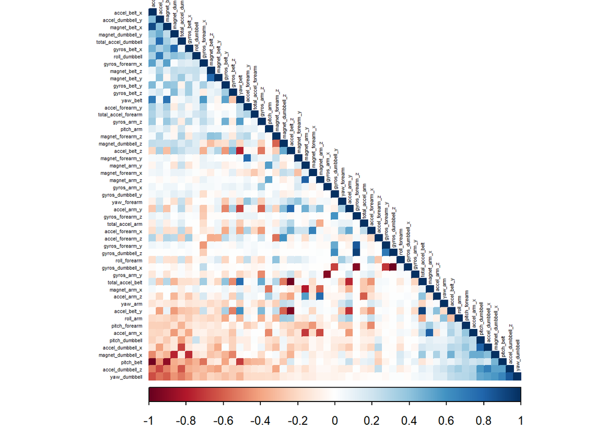

```r
corr <- cor(TrainData [sapply(TrainData, is.numeric)], use = "complete.obs")
corrplot(corr, order = "FPC", method = "color", type = "lower",
         tl.cex = 0.35, tl.col = rgb(0, 0, 0))
```

```r
corcutoff <- findCorrelation(corr, cutoff = .90)
TrainData <- TrainData[,-corcutoff]
TestData <- TestData[,-corcutoff]
```

# Cross Validation

```r
# create a partition with the training dataset
set.seed(11223) # For reproducibile purpose
inTrain  <- createDataPartition(TrainData$classe, p=0.7, list=FALSE)
TrainSet <- TrainData[inTrain, ]
TestSet  <- TrainData[-inTrain, ]
dim(TrainSet)
```

```
## [1] 13453    46
```

## Prediction Model Building

# A: Decision Trees Method

[figure not shown]

```r
DecTree <- rpart(classe ~ ., data=TrainSet, method="class")
fancyRpartPlot(DecTree)
```

```r
# prediction on Test dataset
predictDecTree <- predict(DecTree, newdata=TestSet, type="class")
confMatDecTree <- confusionMatrix(predictDecTree, TestSet$classe)
confMatDecTree
```

```
## Confusion Matrix and Statistics
##
##           Reference
## Prediction    A    B    C    D    E
##          A 1471  205   98   94   84
##          B   74  616   70   96  182
##          C   27  165  801  160  195
##          D   68  110   32  582   95
##          E    1   19    4   12  502
##
## Overall Statistics
##
##                Accuracy : 0.6892
##                  95% CI : (0.6771, 0.7012)
##     No Information Rate : 0.2847
##     P-Value [Acc > NIR] : < 2.2e-16
##
##                   Kappa : 0.6044
##  Mcnemar's Test P-Value : < 2.2e-16
##
## Statistics by Class:
##
##                      Class: A Class: B Class: C Class: D Class: E
## Sensitivity            0.8964   0.5525   0.7970   0.6165  0.47448
## Specificity            0.8833   0.9092   0.8850   0.9367  0.99235
## Pos Pred Value         0.7536   0.5934   0.5942   0.6561  0.93309
## Neg Pred Value         0.9554   0.8944   0.9538   0.9258  0.89359
## Prevalence             0.2847   0.1935   0.1744   0.1638  0.18358
## Detection Rate         0.2552   0.1069   0.1390   0.1010  0.08711
## Detection Prevalence   0.3387   0.1801   0.2339   0.1539  0.09335
## Balanced Accuracy      0.8899   0.7308   0.8410   0.7766  0.73341
```

# B: Random Forests Method

```r
controlRF <- trainControl(method="cv", number=5, verboseIter=FALSE)
modFitRandForest <- train(classe ~ ., data=TrainSet, method="rf",
                          trControl=controlRF)
modFitRandForest$finalModel

# prediction on Test dataset
predictRandForest <- predict(modFitRandForest, newdata=TestSet)
confMatRandForest <- confusionMatrix(predictRandForest, TestSet$classe)
confMatRandForest
```

[output not shown]

# C: Generalized Boosted Method

```r
controlgbm <- trainControl(method = "repeatedcv", number = 5, repeats = 1)
modFitgbm  <- train(classe ~ ., data=TrainSet, method = "gbm",
                    trControl = controlgbm, verbose = FALSE)

# prediction on Test dataset
predictgbm <- predict(modFitgbm, newdata=TestSet)
confMatgbm <- confusionMatrix(predictgbm, TestSet$classe)
confMatgbm
```

```
## Confusion Matrix and Statistics
##
##           Reference
## Prediction    A    B    C    D    E
##          A 1612   49    0    1    4
##          B   15 1032   38    4   13
##          C   10   31  947   36   17
##          D    3    1   17  892   17
##          E    1    2    3   11 1007
##
## Overall Statistics
##
##                Accuracy : 0.9526
##                  95% CI : (0.9468, 0.958)
##     No Information Rate : 0.2847
##     P-Value [Acc > NIR] : < 2.2e-16
##
##                   Kappa : 0.94
##  Mcnemar's Test P-Value : 4.838e-09
##
## Statistics by Class:
##
##                      Class: A Class: B Class: C Class: D Class: E
## Sensitivity            0.9823   0.9256   0.9423   0.9449   0.9518
## Specificity            0.9869   0.9849   0.9802   0.9921   0.9964
## Pos Pred Value         0.9676   0.9365   0.9097   0.9591   0.9834
## Neg Pred Value         0.9929   0.9822   0.9877   0.9892   0.9892
## Prevalence             0.2847   0.1935   0.1744   0.1638   0.1836
## Detection Rate         0.2797   0.1791   0.1643   0.1548   0.1747
## Detection Prevalence   0.2891   0.1912   0.1806   0.1614   0.1777
## Balanced Accuracy      0.9846   0.9553   0.9613   0.9685   0.9741
```

```r
AccuracyResults <- data.frame(
  Model = c('CART', 'GBM', 'RF'),
  Accuracy = rbind(confMatDecTree$overall[1], confMatgbm$overall[1], confMatRandForest$overall[1])
)
print(AccuracyResults)
```

```
##   Model  Accuracy
## 1  CART 0.6892244
## 2   GBM 0.9526288
## 3    RF 0.9930592
```

Considering the accuracy of the three investigated methods, the Random Forest model was selected for validation process on the test data.

# Applying the Selected Model to the Test Data

```r
TestPredict <- predict(modFitRandForest, newdata=TestData)
TestPredictionResults <- data.frame(
  problem_id=TestData$problem_id,
  predicted=TestPredict
)
print(TestPredictionResults)
```

```
##    problem_id predicted
## 1           1         B
## 2           2         A
## 3           3         B
## 4           4         A
## 5           5         A
## 6           6         E
## 7           7         D
## 8           8         B
## 9           9         A
## 10         10         A
## 11         11         B
## 12         12         C
## 13         13         B
## 14         14         A
## 15         15         E
## 16         16         E
## 17         17         A
## 18         18         B
## 19         19         B
## 20         20         B
```

# Conclusion

As seen, the Random Forest model resulted in a highly accurate prediction on the validation data set with accuracy of 0.993 leaving estimated out-of-sample error of 0.69%.